# Problem Set 2 - College Admissions Data

SI 544 Instruction Team

10/25/2019

## Introduction

The total score for this assignment will be 100 points, consisting of: - 90 points: Homework Questions - 10 points: Overall quality of spelling, grammar, punctuation, etc. of written sentences.

As in lecture and discussion, there are several ways to approach and answer these questions! There may not be a “best solution”, but instead a variety of ways to interpret and analyze a given task. Be thoughtful in your responses below your code to explain why you chose the methods and representations in your analysis when prompted for a response.

For further reference regarding quality writing, feel free to refer to Strunk & White’s Elements of Style: https://drive.google.com/file/d/1L0P7xJwjUGBvyb49mL3dw1Bt7hzRTiTl/view?usp=sharing

## The Data

The data set for this assignment consists of college admissions data. It comes from an open data set available via https://www.kaggle.com/mohansacharya/graduate-admissions .

The dataset contains several parameters which are considered important during the application for Masters Programs. The parameters included are:

1. GRE Scores ( out of 340 )
2. TOEFL Scores ( out of 120 )
3. University Rating ( out of 5 )
4. Statement of Purpose and Letter of Recommendation Strength ( out of 5 )
5. Undergraduate GPA ( out of 10 )
6. Research Experience ( either 0 or 1 )
7. Chance of Admit ( ranging from 0 to 1 )

The full citation for the data is:

Mohan S Acharya, Asfia Armaan, Aneeta S Antony : A Comparison of Regression Models for Prediction of Graduate Admissions, IEEE International Conference on Computational Intelligence in Data Science 2019.

Copy the file ‘Admission_Predict.csv’ from the read only folder into your working directory, fill in your name into the string assigned to *MY_UNIQNAME* , then execute the following code block to load the packages and data into your environment.

```r
MY_UNIQNAME = "drewpap"

# Initial setup for our environment
library(tidyverse)
```

```r
library(moderndive)
library(ggplot2)
library(skimr)
# Reading the file in from your working directory
data <- read_csv('Admission_Predict.csv')
data <- data %>% select(gre = "GRE Score", toefl = "TOEFL Score", university_rating = `University Rating`, sop = SOP, lor = LOR, cgpa = CGPA, research=Research,admit = `Chance of Admit`) %>% mutate(research=factor(research))
```

### Question 1 (5 points)

Explain what the previous R code block does.

#### Q1 Response:

The previous block of R code reassigns the data currently in the data variable to itself and renames all of the variables to easier to use names without truncating the meaning of the variables. Then, the code block mutates the research variable to be a factor of itself, effectively converting the research variable into a categorical variable indicating whether that student had research experience or not.

### Question 2 (10 points)

Describe the shape of the distribution of the chance of admission. If you decide to use a histogram choose your width of your bins carefully.

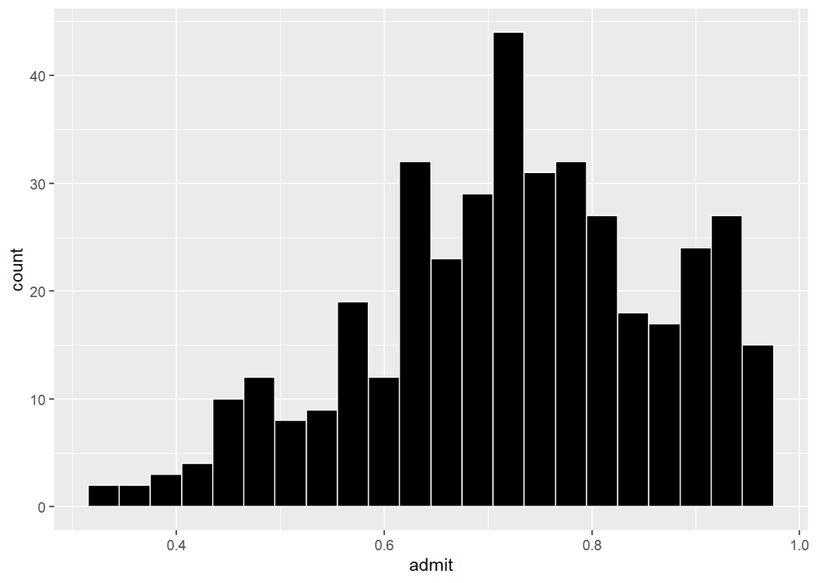

```r
ggplot(data, aes(x = admit))+
  geom_histogram(binwidth = 0.03, color = 'white', fill = 'black')
```

```r
data %>% skim()
```

```
## Skim summary statistics
##  n obs: 400
##  n variables: 8
##
## -- Variable type:factor ------------------------------------------------------------------------------------------------
##  variable missing complete   n n_unique            top_counts ordered
##  research       0      400 400        2 1: 219, 0: 181, NA: 0   FALSE
##
## -- Variable type:numeric -----------------------------------------------------------------------------------------------
##           variable missing complete   n   mean    sd     p0    p25    p50
##              admit       0      400 400   0.72  0.14   0.34   0.64   0.73
##               cgpa       0      400 400   8.6   0.6    6.8    8.17   8.61
##                gre       0      400 400 316.81 11.47 290    308    317
##                lor       0      400 400   3.45  0.9    1      3      3.5
##                sop       0      400 400   3.4   1.01   1      2.5    3.5
##              toefl       0      400 400 107.41  6.07  92    103    107
##  university_rating       0      400 400   3.09  1.14   1      2      3
##     p75   p100     hist
##    0.83   0.97 ▁▂▃▅▇▇▅▅
##    9.06   9.92 ▁▂▃▇▇▇▅▂
##  325    340    ▂▅▅▇▇▇▃▃
##    4      5    ▁▃▃▇▇▇▅▃
##    4      5    ▃▃▆▇▇▇▆▅
##  112    120    ▁▃▅▇▅▇▃▃
##    4      5    ▂▆▁▇▁▅▁▃
```

### Question 3 (10 points)

Create a plot of chance of admission as the outcome variable vs. GRE score as the explanatory variable that shows the line of best fit. Label your axes and use a title or caption for the visualization. Does the lowest GRE score have the least chance of admission?

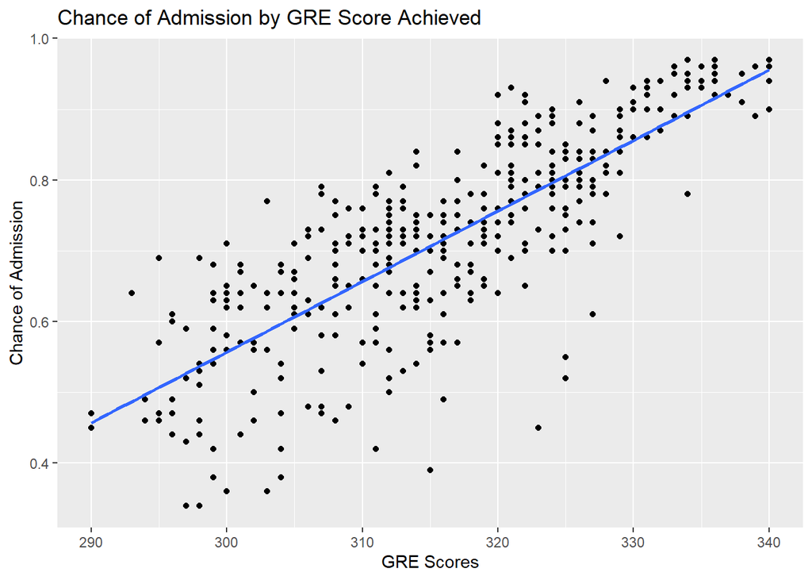

```r
ggplot(data, aes(x = gre, y = admit))+
  geom_point()+
  geom_smooth(method = "lm", se = FALSE)+
  labs(x = "GRE Scores", y = "Chance of Admission", title = "Chance of Admission by GRE Score Achieved")
```

```r
lowest_gre_score <- data %>% select(gre,admit) %>%filter(gre == min(gre))
lowest_admit_chance <- data %>% select(gre,admit) %>% filter(admit == min(admit))

lowest_gre_score
```

```
## # A tibble: 2 x 2
##     gre admit
##   <dbl> <dbl>
## 1   290  0.45
## 2   290  0.47
```

```r
lowest_admit_chance
```

```
## # A tibble: 2 x 2
##     gre admit
##   <dbl> <dbl>
## 1   298  0.34
## 2   297  0.34
```

#### Q3 Response:

To visualize chance of admission as explained by GRE score, I created a scatterplot with GRE score on the X axis and Chance of admission on the Y axis using ggplot.

To find the lowest GRE score and lowest chance of admission, I created two variables named lowest_gre_score and lowest_admit_chance. For each of these, I selected only the gre and admit columns. To get the minimums, I filtered for the minimum gre score of the set and the minimum admit score for the set. Looking at the lowest_gre_score variable, we can see that the lowest GRE score of 290 had an admission rate of 0.45 and 0.47 for two observations. However, when you observe the lowest_admit_chance variable, we see that the lowest admission rate is 0.34 with corresponding GRE scores of 297 and 298 for two observations. Therefore, the lowest GRE score did not necessarily lead to the lowest chance of admission. Because the lowest GRE score is not also associated with the lowest admission rate, we can infer that there are other factors that influence admissions rates besides solely GRE scores.

### Question 4 (15 points)

Create a regression model using chance of admission as the outcome variable and GRE score as the explanatory variable. What are the estimates for the coefficients (intercept and GRE score)?

```r
admit_chance_model <- lm(admit ~ gre, data = data)
get_regression_table(admit_chance_model)
```

```
## # A tibble: 2 x 7
##   term      estimate std_error statistic p_value lower_ci upper_ci
##   <chr>        <dbl>     <dbl>     <dbl>   <dbl>    <dbl>    <dbl>
## 1 intercept    -2.44     0.118     -20.7       0   -2.67    -2.20
## 2 gre           0.01     0          26.8       0    0.009    0.011
```

#### Q4 Response:

To create a regression model to examine the relationship between the chance of admission and GRE score, I created a new variable called admit_chance_model. I assigned a linear model using the lm() function with admit as the y (dependent) variable and GRE score as the x (independent) variable. From there, I used the get_regression_table() function and fed it the linear model created above. By observing the results of the get_regression_table() function, we can see that the estimates for the intercept is -2.436 and 0.010 for the slope. Interpreting this, we can say that for every 1 point increase in GRE score, we would expect to see an increase of 0.010 or 1% increase in chance of admission.

### Question 5 (10 points)

Create a visualization that shows the relationship between Cumulative GPA and the Chance of Admission.  
Use two different colors of lines to show the difference that having research experience makes.  
Describe the effect that having research experience appears to have.

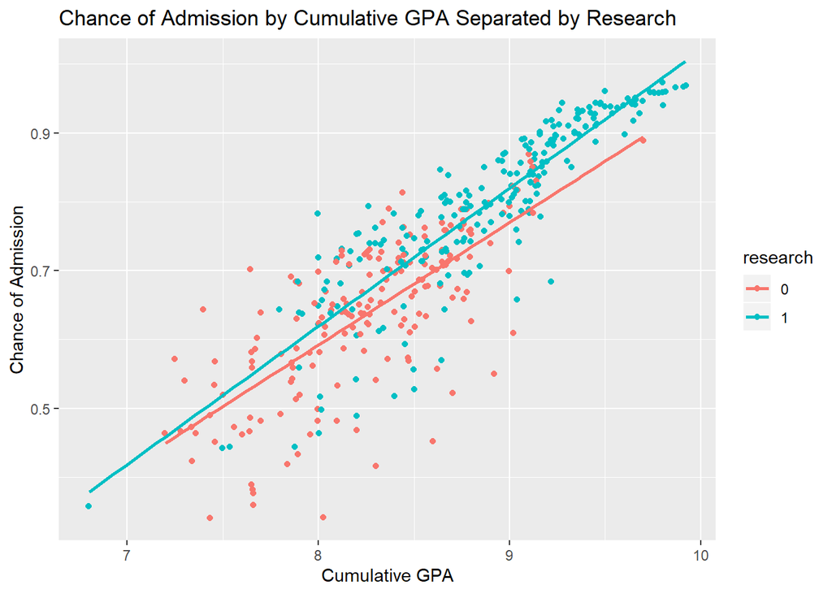

```r
ggplot(data, aes(x = cgpa, y = admit, color = research))+
  geom_jitter()+
  geom_smooth(method = "lm", se = FALSE)+
  labs(x = "Cumulative GPA", y = "Chance of Admission", title = "Chance of Admission by Cumulative GPA Separated by Research")
```

#### Q5 Response:

To view the relationship between cumulative GPA and chance of admission with research experience taken into account, I created a jittered scatterplot using ggplot. I placed cumulative GPA on the X axis and chance of admission on the Y axis because we are seeking to understand the effect of cumulative GPA on the chance of admission. Additionally, I added in research as a color to be able to distinguish those who do and don’t have research experience. I created the two lines of fit by using geom_smooth() with a linear model as the method and two lines were created, one for students with research experience and one for students without research experience. I utilized geom_jitter() instead of geom_point() because there was a clustering of overlapped points towards the 9.5 cumulative GPA section. The jitter helps expose those points slightly better than a straightforward geom_point().

From this visualization it appears that having research experience (research = 1) is associated with a higher chance of admission and cumulative GPA. Looking at the points in the upper right corner, we see an overwheming amount of blue dots. All of the students above a 90% chance of admission had research experience and a cumulative GPA above 9. Looking at the two lines, it is clear that the slopes are different. The line without research experience has a smaller slope, indicating that students without research experience are associated with a lower chance of admission and lower cumulative GPA than their counterparts with research experience.This rule is not concrete however. Students with a cumulative GPA between 8 and 9 saw much more variation in chance of admission. Several students without research experience have higher admission chances than their counterparts without research experience. Overall, research experience does appear to be associated with higher cumulative GPA and chances of admission, so for students seeking to improve their chances of admission, adding research experience to their application will likely not hurt their chances of admission.

### Question 6 (15 points)

Create a regression model that uses chance of admission as the outcome variable and Cumulative GPA *and* research experience as the explanatory variables. What is the expected (estimated) value of the chance of admission for an individual with a cumulative GPA of 9.0 who has research experience.

```r
research_and_gpa_admit_chance_model <- lm(admit ~ cgpa + research + cgpa:research, data = data)
get_regression_table(research_and_gpa_admit_chance_model)
```

```
## # A tibble: 4 x 7
##   term           estimate std_error statistic p_value lower_ci upper_ci
##   <chr>             <dbl>     <dbl>     <dbl>   <dbl>    <dbl>    <dbl>
## 1 intercept        -0.834     0.089     -9.33   0       -1.01    -0.658
## 2 cgpa              0.178     0.011     16.5    0        0.157    0.199
## 3 research1        -0.152     0.117     -1.30   0.193   -0.382    0.077
## 4 cgpa:research1    0.022     0.014      1.64   0.102   -0.005    0.049
```

```r
-0.834 + (-0.152) + (0.178 + 0.022) * 9
```

```
## [1] 0.814
```

#### Q6 Response:

To create a regression model observing the relationship between chance of admission with cumulative GPA and research experience as explanatory variables, I used the lm() function. Instead of assuming there are parallel slopes, I am assuming there is an interaction between the two. As such, I’ve included the term cgpa:research in the function for the linear model, which will compute the model as if there is an interaction. Viewing the model with get_regression_table, we get these two equations:

For no research experience:

```
admit = -0.834 + 0.178 * gpa
```

For research exp:

```
admit = -0.834 + (-0.152) + (0.178 + 0.022) * gpa
```

To calculate the estimtaed chance of admission for a student with research experience and a cumulative GPA of 9.0, we plug the values into the second equation.

```
admit = -0.834 + (-0.152) + (0.178 + 0.022) * 9
admit = 0.814
```

The estimated chance of admission is 0.814 or 81.4% for a student with research experience and a cumulative GPA of 9.0.

### Question 7 (10 points)

Is Cumulative GPA a good predictor of GRE score? Explain your answer.

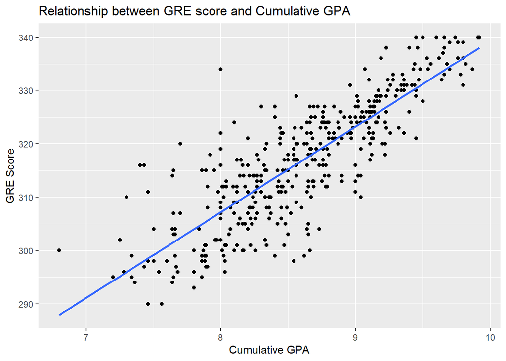

```r
ggplot(data, aes(x = cgpa, y = gre))+
  geom_point()+
  labs(x = "Cumulative GPA",y="GRE Score", title = "Relationship between GRE score and Cumulative GPA")+
  geom_smooth(method = "lm", se = FALSE)
```

```r
data %>%
  get_correlation(gre ~ cgpa)
```

```
## # A tibble: 1 x 1
##   correlation
##         <dbl>
## 1       0.833
```

```r
cgpa_model <- lm(gre ~ cgpa, data = data)
get_regression_table(cgpa_model)
```

```
## # A tibble: 2 x 7
##   term      estimate std_error statistic p_value lower_ci upper_ci
##   <chr>        <dbl>     <dbl>     <dbl>   <dbl>    <dbl>    <dbl>
## 1 intercept    179.      4.60       38.9       0    170.     188.
## 2 cgpa          16.0     0.534      30.0       0     15.0     17.1
```

```r
get_regression_summaries(cgpa_model)
```

```
## # A tibble: 1 x 8
##   r_squared adj_r_squared   mse  rmse sigma statistic p_value    df
##       <dbl>         <dbl> <dbl> <dbl> <dbl>     <dbl>   <dbl> <dbl>
## 1     0.694         0.693  40.2  6.34  6.36      903.       0     2
```

#### Q7 Response:

To examine whether cumulative GPA is a good predictor of GRE score, I created a visualization with ggplot, got the correlation coefficient using the get_correlation() function, and created a linear regression model. Looking at the scatterplot, we can see that there is an association between cumulative GPA and higher GRE scores. Using the get_correlation() function confirms this as the correlation is 0.833, a relatively strong positive correlation. To further confirm this association, let’s look at the results from the linear regression.

From the get_regression_table() function, we the coefficients, which translate to this equation:

gre_hat = 178.977 + 16.029 * cgpa

Interpreting this formula, we would expect that someone with a cumulative GPA of 0 would have a GRE score 0f 178.977. Additionally, for every 1 point of cumulative GPA increase, we would expect an associated increase of 16.029 points on their GRE score.

Looking at the get_regression_summaries() we see an r_squared of 0.694, meaning that around 69.4% of the variance is explained by the model. Overall, the model indicates that cumulative GPA is generally a good predictor for GRE score.

Why is this the case? A possible explanation is that students with good cumulative GPAs are likely hard workers and prioritize their education. As a result, they are more likely to put in effort into studying and practicing for the GRE and see associated gains in their scores.

### Question 8 (15 points)

Which is more important (for the purposes of being admitted): (a) to have a strong letter of reference or (b) to have a strong statement of purpose? Explain your answer.

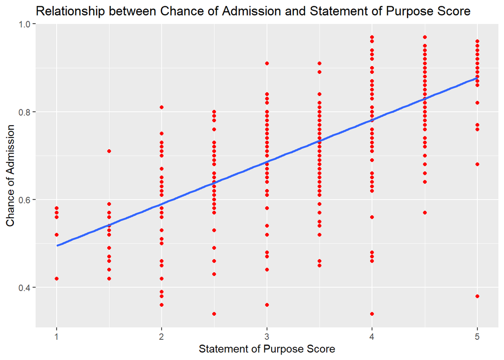

```r
ggplot(data, aes(x = sop, y = admit))+
  geom_point(color = "red")+
  geom_smooth(method = "lm", se = FALSE)+
  labs(x = "Statement of Purpose Score", y = "Chance of Admission", title = "Relationship between Chance of Admission and Statement of Purpose Score")
```

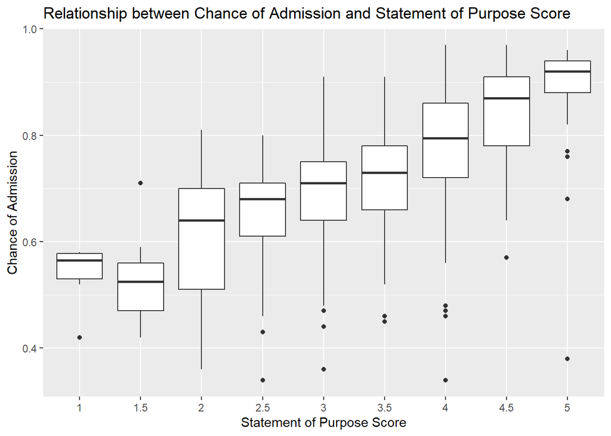

```r
ggplot(data, aes(x = factor(sop), y = admit))+
  geom_boxplot()+
  labs(x = "Statement of Purpose Score", y = "Chance of Admission", title = "Relationship between Chance of Admission and Statement of Purpose Score")
```

```r
sop_model <- lm(admit ~ sop, data)
get_regression_table(sop_model)
```

```
## # A tibble: 2 x 7
##   term      estimate std_error statistic p_value lower_ci upper_ci
##   <chr>        <dbl>     <dbl>     <dbl>   <dbl>    <dbl>    <dbl>
## 1 intercept    0.399     0.019      21.5       0    0.362    0.435
## 2 sop          0.096     0.005      18.3       0    0.085    0.106
```

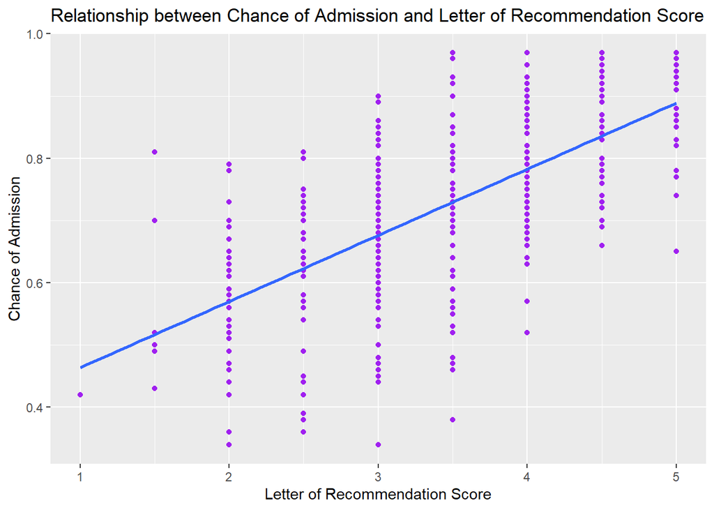

```r
ggplot(data, aes(x = lor, y = admit), color = "blue")+
  geom_point(color = "purple")+
  geom_smooth(method = "lm", se = FALSE)+
  labs(x = "Letter of Recommendation Score", y = "Chance of Admission", title = "Relationship between Chance of Admission and Letter of Recommendation Score")
```

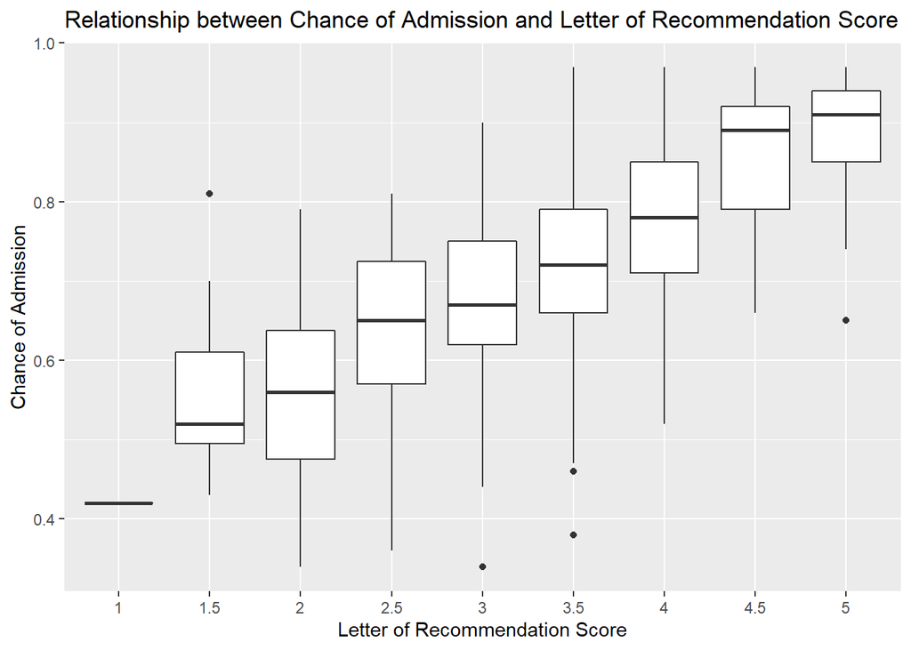

```r
ggplot(data, aes(x = factor(lor), y = admit))+
  geom_boxplot()+
  labs(x = "Letter of Recommendation Score", y = "Chance of Admission", title = "Relationship between Chance of Admission and Letter of Recommendation Score")
```

```r
lor_model <- lm(admit ~ lor, data)
get_regression_table(lor_model)
```

```
## # A tibble: 2 x 7
##   term      estimate std_error statistic p_value lower_ci upper_ci
##   <chr>        <dbl>     <dbl>     <dbl>   <dbl>    <dbl>    <dbl>
## 1 intercept    0.357     0.021      17.0       0    0.316    0.399
## 2 lor          0.106     0.006      18         0    0.095    0.118
```

#### Q8 Response:

To determine whether letter of recommendation or statement of purpose strength is more important for admission chance, I created several visualizations and performed linear regressions for both variables as they relate to admissions chance. Initially, I created scatterplots to visualize the relationship. However, as one can see above, the scatterplots all cluster on 0.5 increments due to the nature of the data. A jittered scatterplot misrepresents the data as well. In order to visually represent the data, I created boxplots that are factored upon statement of purpose and letter of recommendation scores. Observing the boxplots, we can see in both plots that as statement of purpose and letter of recommendation scores increase, so does the chance of admission. The differences between these two boxplots are relatively small. Both sets of boxplots have long whiskers indicating a large amount of variance within the admission chance ranges for those scores. Let’s look at the regression models to see if there is a significant difference there.

Looking at the regression models from the get_regression_table() function, we get these two equations:

For statement of purpose:

chance_of_admission_hat = 0.399 + 0.096 * statement_of_purpose_score

For letter of recommendation:

letter_of_recommendation_hat = 0.357 + 0.106 * letter_of_recommendation_score

Given these equations, it is difficult to tell whether statement of purpose score or letter of recommendation score is more important for admission chance. On the one hand, letter of recommendation score has a higher slope, meaning that each point of score towards their letter of recommendation is associated with a higher gain in admission chance compared to an equal increase in statement of purpose score. However, statement of purpose has a higher intercept, meaning that statement of purpose scores start higher to begin with compared to letter of recommendation scores. There is no clear winner in terms of which is more important for increasing admission chance. This is especially so if you look at the confidence intervals for both regressions. The confidence intervals overlap for both the intercept and the slope for each regression. This means that there is a possibility that both letter of recommendation and statement of purpose have the same slope and intercept and that the variation we see is only a result of variation in sampling. This probably isn’t the case, but it is not impossible to imagine given the current confidence intervals. As such, there does not seem to be a clear winner in terms of letter of recommendation score and statement of purpose score on chance of admission.